# Understanding patterns of species abundance and persistence in PPA

In this document, I examine how a species’ performance in mixture depends on 1) its monoculture biomass and 2) its trait values. To measure performance in mixture, I use two indices: 1) total biomass and 2) time to extinction.

## 0.1 Monoculture biomass in relation to trait values

First, a facetted plot of the relationship between each species’ trait values and its corresponding monoculture biomass.

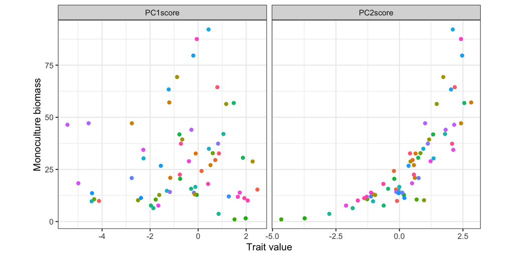

```r
PPA.monocultures <- PPA %>%
    filter(Ninitial == 1,
           Year == 200) %>%
    rename(monoculture.biomass = Biomass) %>%
    select(-Ninitial, -Stage, -Year, -Rep) %>%
    pivot_longer(c(-SpeciesID, -monoculture.biomass),
                 names_to = "trait",
                 values_to = "trait.value")

ggplot(PPA.monocultures) +
    geom_point(aes(x = trait.value,
                   y = monoculture.biomass,
                   color = SpeciesID)) +
    facet_wrap(facets = vars(trait),
               ncol = 4,
               scales = "free_x") +
    labs(x = "Trait value",
         y = "Monoculture biomass") +
    theme_bw() +
    theme(aspect.ratio = 1,
          legend.position = "none")
```

PC2score has a much more clear relationship with monoculture biomass at the end of the simulation than PC1score.

A more concise plot, incorporating both PCA scores into one facet.

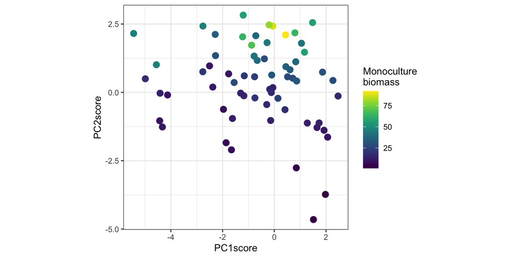

```r
PPA.monocultures <- PPA %>%
    filter(Ninitial == 1,
           Year == 200) %>%
    select(-Ninitial, -Stage, -Year, -Rep)

ggplot(PPA.monocultures) +
    geom_point(aes(x = PC1score,
                   y = PC2score,
                   color = Biomass),
               size = 3) +
    scale_color_viridis() +
    labs(color = "Monoculture\nbiomass") +
    theme_bw() +
    theme(aspect.ratio = 1)
```

The relationship between PC1score and PC2score in driving monoculture biomass production is nonlinear. Although maximizing PC2score seems to be predictive of a high monoculture biomass, species with moderately high PC1scores potentially produce more biomass than species of identical PC2scores but even higher PC1scores.

# 1 Competitive ability in mixture vs. monoculture biomass

I now shift focus towards understanding how a species’ competitive ability - its ability to produce biomass, or persist within the community - changes with its position in trait space. To do so, I use first the 32-species mixtures and then the 64-species mixture.

## 1.1 32-species mixtures

### 1.1.1 Species’ biomass in 32-species mixture vs. their biomass in monoculture

For these first few graphs, I include the biomass measurements in the last step of the metacommunity stage - with seed addition - as well.

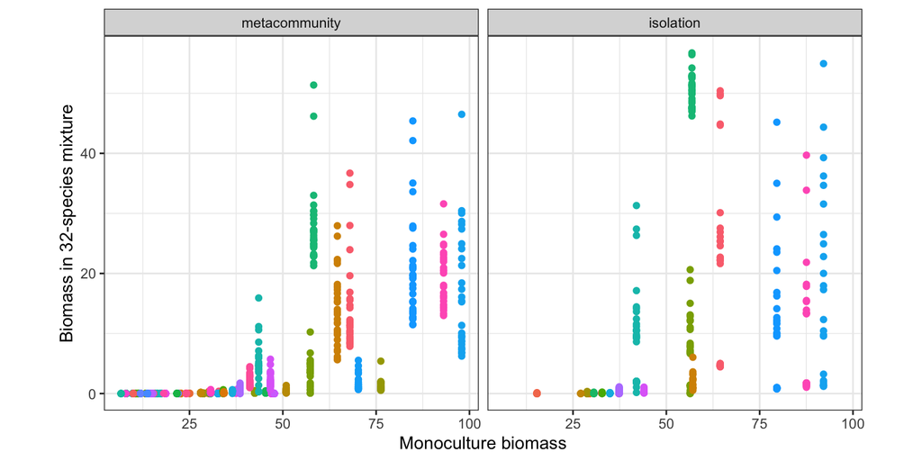

```r
PPA.monocultures <- PPA %>%
    filter(Ninitial == 1,
           Year %in% c(100, 200)) %>%
    rename(monoculture.biomass = Biomass) %>%
    select(-Ninitial, -Year, -Rep)

PPA.32 <- PPA %>%
    filter(Ninitial == 32,
           Year %in% c(100, 200)) %>%
    select(SpeciesID, Stage, Biomass, PC1score, PC2score)

PPA.combined <- inner_join(PPA.monocultures, PPA.32)

ggplot(PPA.combined) +
    geom_point(aes(x = monoculture.biomass,
                   y = Biomass,
                   color = SpeciesID)) +
    facet_grid(cols = vars(Stage)) +
    labs(x = "Monoculture biomass",
         y = "Biomass in 32-species mixture") +
    theme_bw() +
    theme(aspect.ratio = 1,
          legend.position = "none")
```

Within 32-species communities, a truly low monoculture biomass does not tend to translate into biomass in mixture. However, several of the most fit species within mixture are those with moderate levels of biomass in monoculture. There is a large degree of variation in the biomass in mixture for many of the species.

### 1.1.2 Species’ biomass in 32-species mixture vs. its traits, disentangled

Now I shift towards understanding how these patterns of biomass production in mixture stem from the species’ underlying traits.

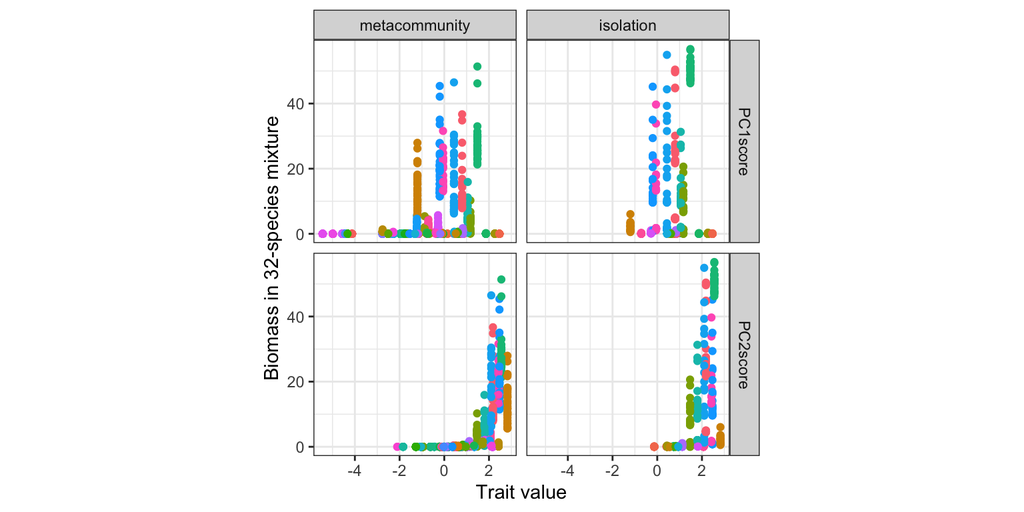

```r
PPA.32 <- PPA %>%
    filter(Ninitial == 32,
           Year %in% c(100, 200)) %>%
    select(SpeciesID, Stage, Biomass, PC1score, PC2score)

PPA.32 <- PPA.32 %>%
    pivot_longer(c(-SpeciesID, -Stage, -Biomass),
                 names_to = "trait",
                 values_to = "trait.value")

ggplot(PPA.32) +
    geom_point(aes(x = trait.value,
                   y = Biomass,
                   color = SpeciesID)) +
    facet_grid(cols = vars(Stage),
               rows = vars(trait)) +
    labs(x = "Trait value",
         y = "Biomass in 32-species mixture") +
    theme_bw() +
    theme(aspect.ratio = 1,
          legend.position = "none")
```

It is difficult to derive consistent takeaways from this plot. It seems that species with high trait values on the second PCA axis are competitively dominant.

### 1.1.3 Species’ biomass in 32-species mixture vs. its traits

To sharpen the comparison between species’ traits and their in-mixture biomass production, I tie both traits to plot axes and biomass production to the color of the points.

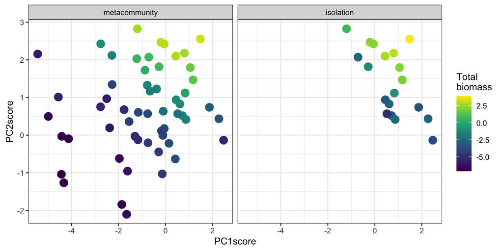

```r
PPA.32 <- PPA %>%
    filter(Ninitial == 32,
           Year %in% c(100, 200)) %>%
    group_by(SpeciesID, Stage, PC1score, PC2score) %>%
    summarise(Biomass = mean(Biomass)) %>%
    filter(Biomass > 0)

ggplot(PPA.32) +
    geom_point(aes(x = PC1score,
                   y = PC2score,
                   color = log(Biomass)),
               size = 4) +
    facet_grid(cols = vars(Stage)) +
    scale_color_viridis() +
    labs(color = "Total\nbiomass") +
    theme_bw() +
    theme(aspect.ratio = 1)
```

Here, it becomes apparent that within the community mixtures, those species that maximize both PCA axes are those that dominate the community. Indeed, the competitive dominant within the simulation has the highest summed trait values.

### 1.1.4 Time to extinction in 32-species mixture vs. biomass in monoculture

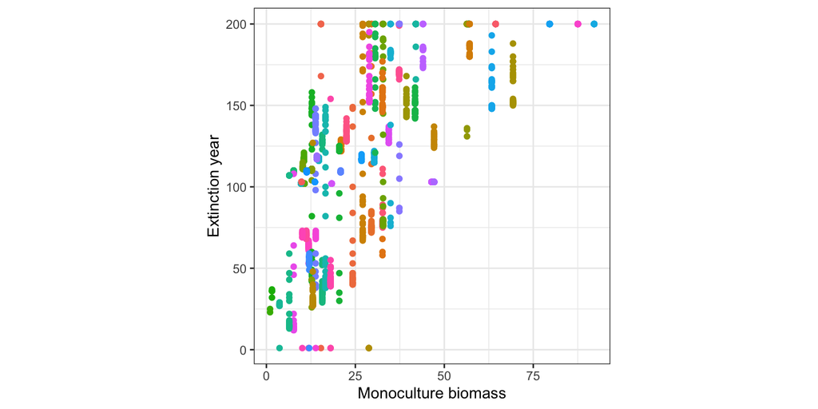

```r
PPA.monocultures <- PPA %>%
    filter(Ninitial == 1,
           Year == 200) %>%
    rename(monoculture.biomass = Biomass) %>%
    select(-Ninitial, -Stage, -Year, -Rep)

PPA.32 <- PPA %>%
    filter(Ninitial == 32)

PPA.32 <- PPA.32 %>%
    group_by(SpeciesID, Rep) %>%
    arrange(Year) %>%
    mutate(isDead = (Biomass == 0)) %>%
    filter(isDead | (!isDead & Year == max(Year))) %>%
    filter(Year == first(Year))

PPA.combined <- inner_join(PPA.monocultures, PPA.32)

ggplot(PPA.combined) +
    geom_point(aes(x = monoculture.biomass,
                   y = Year,
                   color = SpeciesID)) +
    labs(x = "Monoculture biomass",
         y = "Extinction year") +
    theme_bw() +
    theme(aspect.ratio = 1,
          legend.position = "none")
```

Generally species, species with high monoculture biomasses persist for the longest duration of time. However, this is a great degree of variation within this pattern.

### 1.1.5 Time to extinction in 32-species mixture vs. traits

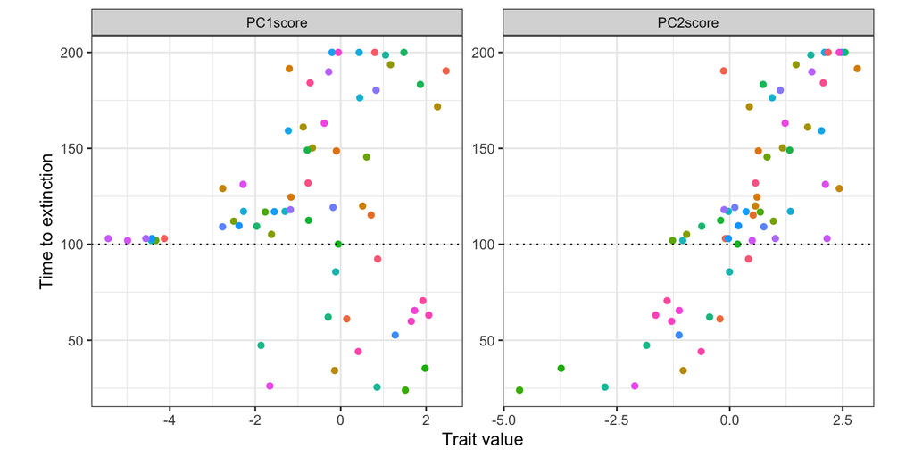

```r
PPA.32 <- PPA %>%
    filter(Ninitial == 32)

PPA.32 <- PPA.32 %>%
    group_by(SpeciesID, Rep) %>%
    arrange(Year) %>%
    mutate(isDead = (Biomass == 0)) %>%
    filter(isDead | (!isDead & Year == max(Year))) %>%
    filter(Year == first(Year))

PPA.32 <- PPA.32 %>%
    group_by(SpeciesID, PC1score, PC2score) %>%
    summarise(Year = mean(Year))

PPA.32 <- PPA.32 %>%
    pivot_longer(c(-SpeciesID, -Year),
                 names_to = "trait",
                 values_to = "trait.value")

ggplot(PPA.32) +
    geom_point(aes(x = trait.value,
                   y = Year,
                   color = SpeciesID)) +
    geom_hline(yintercept = 100,
               linetype = 3) +
    facet_wrap(facets = vars(trait),
               ncol = 4,
               scales = "free") +
    labs(x = "Trait value",
         y = "Time to extinction") +
    theme_bw() +
    theme(aspect.ratio = 1,
          legend.position = "none")
```

While there is a linear relationship between PC2score and extinction time, the relationship between PC1score is more complex. The most striking result of this graph is that species with very low PC1scores are extirpated almost immediately after seed addition is turned off (the dashed line), regardless of their PC2score. After this filter, it appears that the relationship between time to extinction and PC1score is somewhat linear, with higher trait values seeing longer persistance times within the community.

Again, I put both trait axes into one facet to sharpen the comparison.

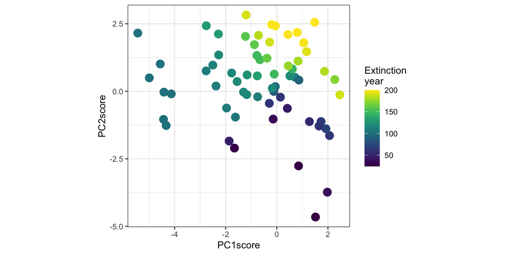

```r
PPA.32 <- PPA %>%
    filter(Ninitial == 32)

PPA.32 <- PPA.32 %>%
    group_by(SpeciesID, Rep) %>%
    arrange(Year) %>%
    mutate(isDead = (Biomass == 0)) %>%
    filter(isDead | (!isDead & Year == max(Year))) %>%
    filter(Year == first(Year))

PPA.32 <- PPA.32 %>%
    group_by(SpeciesID, PC1score, PC2score) %>%
    summarise(Year = mean(Year))

ggplot(PPA.32) +
    geom_point(aes(x = PC1score,
                   y = PC2score,
                   color = Year),
               size = 4) +
    labs(color = "Extinction\nyear") +
    scale_color_viridis() +
    theme_bw() +
    theme(aspect.ratio = 1)
```

The relationship between extinction time and the two trait axes looks almost identical to that of biomass production and trait values.

### 1.1.6 Contextualizing the importance of traits in monoculture and mixture

In the following section, I train two random forests, one on the monoculture dataset and the other on the 32-species mixture dataset. I compare relative importance of the two trait axes within these two contexts, and then use the two random forests to predict biomass across a range of trait values to show how the fitness of different trait combinations changes based on context.

In both random forests, because the algorithm is “data hungry,” I use the last 20 years of data (e.g., I feed it years 180 - 200). I incorporate `Year` as a predictor variable in both, to ensure that it does not bias the results. However, since random forests are a nonparametric tool, they should be robust to any underlying autocorrelation in the biomass dataset.

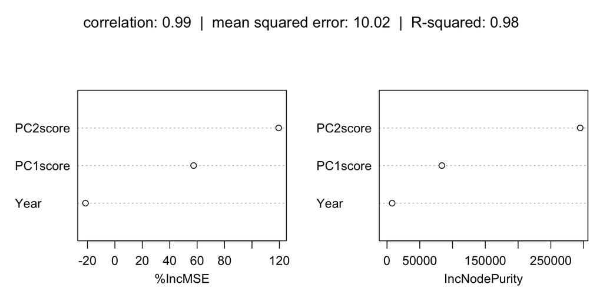

```r
PPA.monocultures <- PPA %>%
    filter(Ninitial == 1,
           Year %in% seq(180, 200)) %>%
    mutate(id = row_number()) %>%
    mutate_if(is.character, as.factor) %>%
    select(-SpeciesID, -Ninitial, -Stage, -Rep)

train <- PPA.monocultures %>% sample_frac(.70)
test <- anti_join(PPA.monocultures, train, by = 'id')

train <- train %>% select(-id)
test <- test %>% select(-id)

rf.monocultures <- randomForest(data = as.data.frame(train),
                                Biomass ~ .,
                                importance = TRUE)

pred <- data.frame(pred = predict(rf.monocultures, test))
title = paste("correlation: ", round(cor(pred, test$Biomass)[[1]], 2),
              "  |  mean squared error: ", round(mean(rf.monocultures$mse), 2),
              "  |  R-squared: ", round(mean(rf.monocultures$rsq), 2),
              sep = "")

varImpPlot(rf.monocultures, main = title)
```

In determining monoculture biomass, PC2score is considerably more important than PC1score. Year is a poor predictor of total biomass, so I trust that autocorrelation in time does not significantly bias the importance values of the two PCA axes and predictions of the results.

Note that in the above variable importance plot, the correlation between the testing dataset’s realized monoculture biomasses and the random forest’s predictions of this biomass is nearly 1. The pseudo R-squared of the random forest regression model is also nearly 1. This indicates that patterns in monoculture biomass production in the PPA model can be entirely explained by the two traits. This confirmation of intuition suggests that the random forest is doing its job correctly.

Now, I use a random forest on the 32-species mixtures to see how the importance of the two trait axes change in competition.

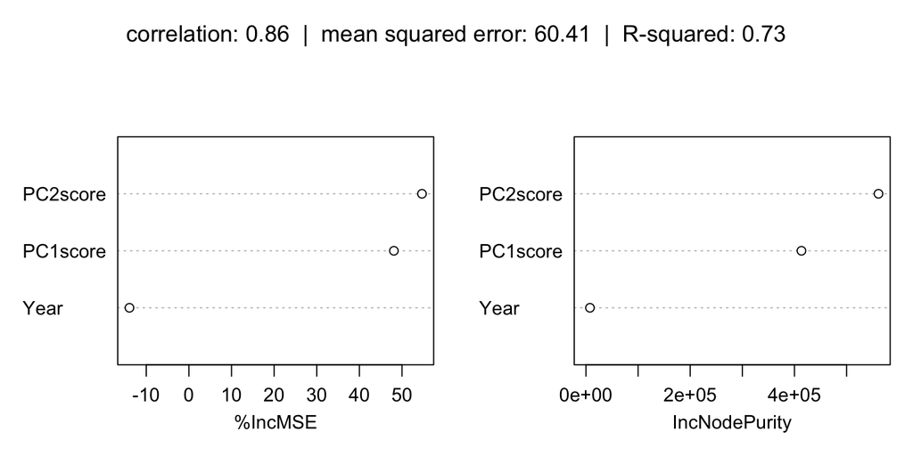

```r
PPA.32 <- PPA %>%
    filter(Ninitial == 32,
           Year %in% seq(180, 200)) %>%
    mutate(id = row_number()) %>%
    mutate_if(is.character, as.factor) %>%
    select(-SpeciesID, -Ninitial, -Stage, -Rep)

train <- PPA.32 %>% sample_frac(.70)
test <- anti_join(PPA.32, train, by = 'id')

train <- train %>% select(-id)
test <- test %>% select(-id)

rf.32 <- randomForest(data = as.data.frame(train),
                      Biomass ~ .,
                      importance = TRUE)

pred <- data.frame(pred = predict(rf.32, test))
title = paste("correlation: ", round(cor(pred, test$Biomass)[[1]], 2),
              "  |  mean squared error: ", round(mean(rf.32$mse), 2),
              "  |  R-squared: ", round(mean(rf.32$rsq), 2),
              sep = "")

varImpPlot(rf.32, main = title)
```

The relative importance of PC1score increases dramatically, indicating that while relatively unimportant for monoculture biomass production, the first PCA axis becomes critical for determining total biomass within the context of a community.

Note the decline in both correlation with the testing dataset and the psuedo R-squared. This suggests that within a community context, interactions between species within the community add variation to the emergent biomass per species. Because the random forest is simply looking at the species’ traits, it cannot fully capture the variation in biomass production that is caused by interactions within the community. In other words, based on which species are included in a given initial community, a species may have higher or lower biomass.

Now, I will predict the biomass production of species as monocultures and in mixture based on where they lie in trait space.

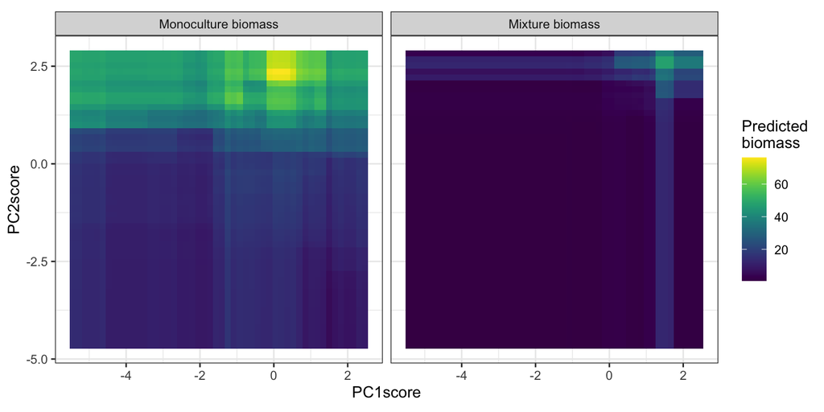

```r
grid <- expand_grid(PC1score = seq(min(PPA$PC1score), max(PPA$PC1score), length.out = 50),
                    PC2score = seq(min(PPA$PC2score), max(PPA$PC2score), length.out = 50),
                    Year = 200)

grid$`Monoculture biomass` <- stats::predict(rf.monocultures, grid)
grid$`Mixture biomass` <- stats::predict(rf.32, grid)

grid <- grid %>%
    group_by(PC1score, PC2score) %>%
    pivot_longer(c(-PC1score, -PC2score, -Year),
                 names_to = "treatment",
                 values_to = "biomass")

grid$treatment <- fct_relevel(grid$treatment,
                              "Monoculture biomass", "Mixture biomass")

# Derive plots
ggplot(grid) +
    geom_tile(aes(x = PC1score,
                  y = PC2score,
                  fill = biomass)) +
    facet_grid(cols = vars(treatment)) +
    scale_fill_viridis() +
    labs(fill = "Predicted\nbiomass") +
    theme_bw() +
    theme(aspect.ratio = 1)
```

This plot puts into relief the shift in importance for the first PCA axis. In monocultures, the dominant determinant of total biomass is the second PCA axis; while species with PC1scores near zero tend to have higher monoculture biomasses than those with very low PC1scores (e.g. -4), even these low PC1scores have considerable monoculture biomasses. However, in mixture, the first PCA axis becomes critical in determining competitive ability, and the highest biomass achieving trait combination shifts towards higher PC1scores.

An important caviate:

> Using the random forest to extrapolate the biomass production of trait combinations that are not present in the original set of species should be taken with a grain of salt. For example, the species with the highest level of biomass production in mixture maximizes both trait axes. This pattern is not seen in the random forest’s predictions: Instead, very high, but not maximized, values from PC1 are dominant. This is an artifact, rather than a reality. I could improve this this methodology by using partial dependency plots and contraining the algorithm to not extrapolate outside of the convex hull of data points.

## 1.2 64-species mixture

### 1.2.1 Biomass in the 64-species mixture vs. monoculture biomass

To understand how these dynamics change with seed addition, I incorporate the `metacommunity` phase into the following analysis of 64-species mixtures. During the `metacommunity` phase, seed addition is present.

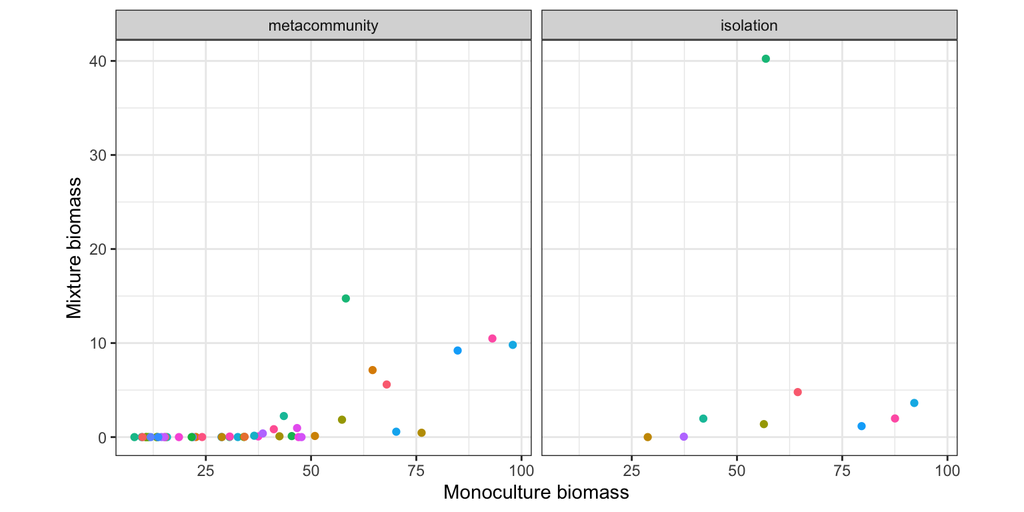

```r
PPA.monocultures <- PPA %>%
    filter(Ninitial == 1,
           Year %in% c(100, 200)) %>%
    rename(monoculture.biomass = Biomass) %>%
    select(-Ninitial, -Year, -Rep)

PPA.mixture <- PPA %>%
    filter(Ninitial == 64,
           Year %in% c(100, 200)) %>%
    rename(mixture.biomass = Biomass) %>%
    select(-Ninitial, -Year, -Rep)

PPA.combined <- inner_join(PPA.monocultures, PPA.mixture)

ggplot(PPA.combined) +
    geom_point(aes(x = monoculture.biomass,
                   y = mixture.biomass,
                   color = SpeciesID)) +
    facet_grid(cols = vars(Stage)) +
    labs(x = "Monoculture biomass",
         y = "Mixture biomass") +
    theme_bw() +
    theme(aspect.ratio = 1,
          legend.position = "none")
```

### 1.2.2 Biomass in the 64-species mixture vs. traits over time

This plot is animated to show how the species within the 64-species mixture are thinned over time. The size of each point is relative to its biomass, while the color is its species identity.

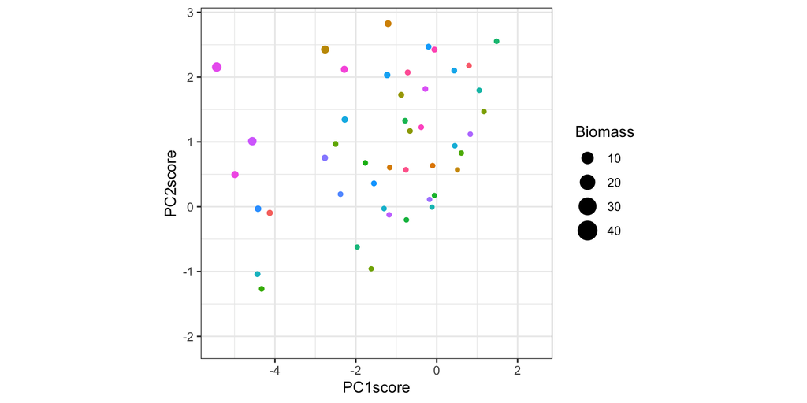

```r
PPA.64 <- PPA %>%
    filter(Ninitial == 64)

ggplot(PPA.64) +
    geom_point(aes(x = PC1score,
                   y = PC2score,
                   color = SpeciesID,
                   size = Biomass)) +
    scale_colour_discrete(guide = FALSE) +
    transition_time(Year) +
    theme_bw() +
    theme(aspect.ratio = 1)
```

### 1.2.3 Time to extinction in 64-species mixture vs. monoculture biomass

And now, again, the time to extinction.

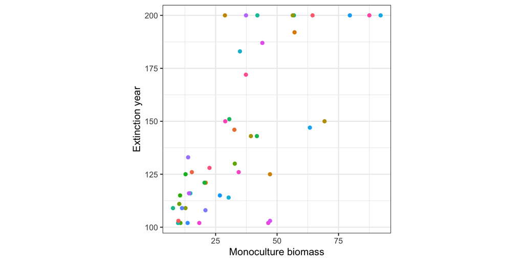

```r
PPA.monocultures <- PPA %>%
    filter(Ninitial == 1,
           Year == 200) %>%
    rename(monoculture.biomass = Biomass) %>%
    select(-Ninitial, -Year, -Rep)

PPA.64 <- PPA %>%
    filter(Ninitial == 64) %>%
    select(-Ninitial, -Rep)

PPA.64 <- PPA.64 %>%
    group_by(SpeciesID) %>%
    arrange(Year) %>%
    mutate(isDead = (Biomass == 0)) %>%
    filter(isDead | (!isDead & Year == max(Year))) %>%
    filter(Year == first(Year))

PPA.combined <- inner_join(PPA.monocultures, PPA.64)

ggplot(PPA.combined) +
    geom_point(aes(x = monoculture.biomass,
                   y = Year,
                   color = SpeciesID)) +
    labs(x = "Monoculture biomass",
         y = "Extinction year") +
    theme_bw() +
    theme(aspect.ratio = 1,
          legend.position = "none")
```